# HANDOUT8

LUIS SASTRE SAN EMETERIO

10/26/2019

# Ejercicio 1

## (3)

### Para que se cumpla la propiedas STCP, se debe cumplir que si el nodo “u” tiene una conexion fuerte con los nodos “v” y “w”, entonces tiene que haber una conexion debil o fuerte entre “v” y “w”.

### En este caso, quienes satisfacen dicha conexion son los nodas “B”, “D” y “A”. Los que no son “C” y “E”, ya que “C” esta conectado fuertemente a “B” y a “E”, pero entre ellos no hay ninguna conexion. Y lo mismo pasa con “E”.

## (4)

### Para que se cumpla la propiedas STCP, se debe cumplir que si el nodo “u” tiene una conexion fuerte con los nodos “v” y “w”, entonces tiene que haber una conexion debil o fuerte entre “v” y “w”.

### En este caso, quienes violan dicha conexion son los nodas “C” y “E”.

## (5)

### Para que se cumpla la propiedas STCP, se debe cumplir que si el nodo “u” tiene una conexion fuerte con los nodos “v” y “w”, entonces tiene que haber una conexion debil o fuerte entre “v” y “w”.

### En este caso, quienes satisfacen dicha conexion son los nodas “A”, “B”, “D” y “E”. El que no es “C”, ya que “C” esta conectado fuertemente a “A” y a “E”, pero entre ellos no hay ninguna conexion.

# Ejercicio 2

### Voy a cargar el dataframe y como es muy grande lo he divido en un subgrafo de 1000 nodos para hacer el ejercicio.

[figure not shown]

```r
Data <- read.table("WikiVote.txt",quote = "\"", comment.char = "")
wiki <- graph_from_data_frame(d = Data,directed = FALSE)
plot(wiki)
```

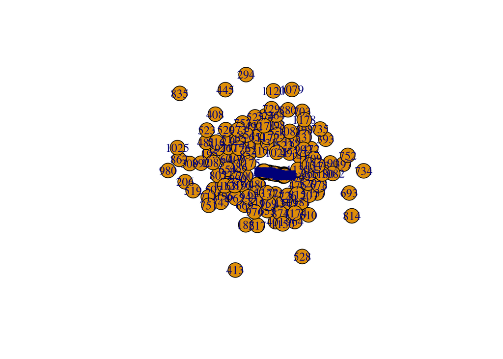

```r
sg <- induced_subgraph(wiki, 1:1000)
plot(sg)
```

## (1)

```r
C.EB <- cluster_edge_betweenness(sg)
membership(C.EB)
```

```
##   30    3   25    4    5    6    7    8    9   10   11   12   13   14   15
##    1    2    3    4    5    6    7    6    8    9    6   10   11   12    6
##   16   17   18   19   20   21   22   23   24   54   28   33   34   36   35
##   13   14   15   16    6   17   18   19    6   20    6   21   22    6    6
##   37   38   39   40   26   41   42   43   44   45   46   47   48   49   50
##   23   24   25   26   27   28   29   30   31   32   33   34   35   36   37
##   51   52   53   29   55   56   57   58   59   60   62   27   63   64   65
##   38   39   40    6    6    6   41   42   43   44   45   46   47   48   49
##   66   72   73   75   76   78   79   77   80   81   83   91   67   84   85
##   50    6   51   52   53   54   55   56   57   58   59   60   61   62   63
##   86   71   87   88   89   90   93   92   82   94   95   99   96  100   98
##    6   64    6   65   66   67   68   69   70   71   72   73   74   75   76
##   31  102  103  115  116  104  105  106   68  117  118  119  107  108  109
##   77   72   78   72   72   79   80   81   82   72   72   72   72   83   84
##  110  111  120  112  121  122  113  123  124  114  130  126  127  128  129
```

[output cut: 119 more lines]

[figure not shown]

```r
plot_dendrogram(C.EB)
```

## (2)

### Al no poder representar el “cluster_fast_greedy con”sg" he tenido que hacerlo mas pequeño.

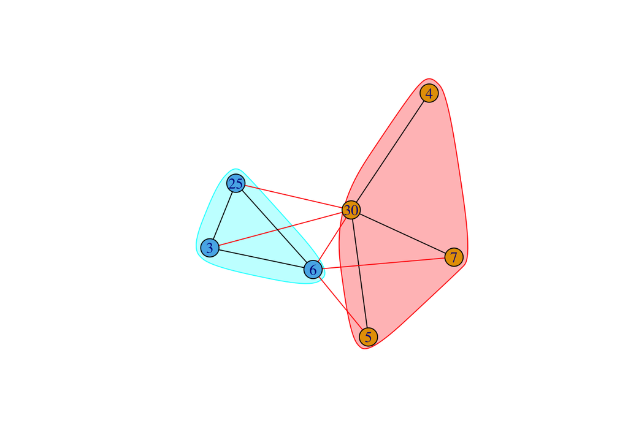

```r
sg1 <- induced_subgraph(wiki,1:7)
C.FG <- cluster_fast_greedy(sg1, modularity = T)
plot(C.FG, sg1)
```

## (3)

```r
M <- as.matrix(as_adjacency_matrix(sg))
prestige(M, gmode = "graph", cmode = "indegree")
```

```
##    [1]  23  47  65  24  20 158  15 159  47  74 209  35   7  51 100   8  31
##   [18]   8  49  94  46   1  69  85  43 205  47  25 111 133   7  24  58   7
##   [35]  61  15  38   3  12   4  30  55  12  30  40  13   1   3 117 110 113
##   [52]   7  19  36   0   6  49   1   3   2  14 111   8  83   1  13  26  12
##   [69]  82  10   2   2  11   1   1 150  36  54   1  29  35  18   4   1  75
##   [86]  33   1   2   4   5   6   3  17   2   1  18  24   5  19   1   1   1
##  [103]   1  12  10  45  17   3   1   4  14  26   1   2   1  30  17  51  24
##  [120]   3  41   5   1  37  18   0  45  18  40   0  13  42  31   6   1  76
##  [137]   1  64  19  49   8   4  26   4   1   1  12   3  14   2  29  72  16
##  [154]  20  97   1  42  19   8  63  11  13   0  62  30   1   2  23   0  16
##  [171]   0   0   0   6   0   0   2   6   0  13   4   5  58  10   0   0   3
##  [188]   6  39   0  19  24  34   0   8   4  16  23   1  31   3  27  48   2
##  [205]  85   2   3  24   5  26  25  33   1   1   1  49  11   1   1   1   3
##  [222]  30   1  15  77   8  29  16   3  76   9   0  13   6   0   2  17   3
##  [239]  18   3   1  20   5  54 125   2   3  17   1   1   1   2   0   3   1
```

[output cut: 44 more lines]